# Taller 3 - Tipos de Datos y Estructuras

Laura Katherine Martinez Castiblanco

# Ejercicio 1: Clasificación de tipos de datos

Para cada fuente de datos, indique: (a) si es estructurada, semi-estructurada o no estructurada; (b) la razón; (c) el paso de preprocesamiento mínimo para convertirla en un tibble analizable.

### 1. Microdatos GEIH del DANE (Archivo `.csv` de 300.000 filas)

- **(a) Clasificación:** **Estructurado**.
- **(b) Razón:** Posee un esquema explícito rígido predefinido donde cada columna representa una variable con tipo de dato fijo (entero, numérico, carácter) y cada fila corresponde a una observación (hogar/persona). No requiere parsing de árbol ni inferencia de etiquetas en memoria.
- **(c) Paso de preprocesamiento mínimo:**
  1. Lectura directa mediante `readr::read_csv()` por su eficiencia computacional en archivos de gran tamaño (300k+ filas).
  2. Especificación explícita de tipos de columna (`col_types`) y codificación de caracteres (`locale = locale(encoding = "Latin1")`).
  3. Estandarización de nombres con `janitor::clean_names()` y tratamiento de valores faltantes (`NA`).

```r
# Ejemplo
geih_raw <- readr::read_csv(
  file = "geih_microdatos.csv",
  locale = readr::locale(encoding = "Latin1"),
  show_col_types = FALSE
) %>%
  janitor::clean_names()
```

### 2. Respuesta JSON de la API pública datos.gov.co (Calidad del aire)

- **(a) Clasificación:** **Semi-estructurado**.
- **(b) Razón:** No sigue un esquema relacional estricto, sino una auto-descripción jerárquica mediante pares clave-valor (`key-value`). Aunque `jsonlite::fromJSON()` convierte arreglos simples automáticamente, los campos anidados (como coordenadas o listas de sensores) impiden que sea una matriz o tabla plana bidimensional inmediata.
- **(c) Paso de preprocesamiento mínimo:**
  1. Consumo del endpoint o archivo local con `jsonlite::fromJSON()`.
  2. Aplanamiento jerárquico (*flattening*) y desanidado de listas mediante `tidyr::hoist()` o `tidyr::unnest_wider()` para extraer las métricas (PM2.5, PM10) a vectores numéricos en columnas.
  3. Conversión de las marcas de tiempo a objetos `POSIXct` de fecha/hora.

```r
# Ejemplo
json_raw <- jsonlite::fromJSON("https://datos.gov.co/resource/calidad_aire.json")
json_tbl <- as_tibble(json_raw) %>%
  tidyr::hoist(ubicacion, latitud = "lat", longitud = "lng") %>%
  dplyr::mutate(concentracion_pm25 = as.numeric(concentracion_pm25))
```

### 3. Grabaciones de audio de audiencias judiciales de la Rama Judicial

- **(a) Clasificación:** **No estructurado**.
- **(b) Razón:** Es una señal física/acústica continua representada como una secuencia temporal de amplitudes sonoras sin campos, columnas o etiquetas semánticas predefinidas. Un algoritmo de minería tradicional (ej. árboles de decisión o regresión) no puede operar directamente sobre el archivo binario sin una transformación representacional.
- **(c) Paso de preprocesamiento mínimo (Dos enfoques según el objetivo de KDD):**
  - **Opción A (Minería de Texto / NLP):** Transcripción automática mediante un modelo ASR (*Automatic Speech Recognition* como OpenAI Whisper), seguido de limpieza de texto, remoción de *stop words*, tokenización y vectorización en una matriz de términos-documentos (TF-IDF o *embeddings*).
  - **Opción B (Procesamiento de Señal Acústica):** Ventaneo del audio y extracción de características espectrales numéricas (Coeficientes Cepstrales en las Frecuencias de Mel - MFCC, tono, energía) agrupadas en un `tibble` o matriz bidimensional $X \in \mathbb{R}^{n \times p}$.

### 4. Factura electrónica emitida por la DIAN (Formato XML)

- **(a) Clasificación:** **Semi-estructurado**.
- **(b) Razón:** Está estructurado jerárquicamente en forma de árbol (*XML Schema* / UBL) utilizando etiquetas delimitadoras (`<Invoice>`, `<LegalMonetaryTotal>`, `<InvoiceLine>`). Posee léxico estructural estandarizado, pero no es una tabla rectangular bidimensional directa.
- **(c) Paso de preprocesamiento mínimo:**
  1. Lectura del documento XML con `xml2::read_xml()`.
  2. Extracción de nodos clave con expresiones XPath (`xml2::xml_find_all()`, `xml2::xml_text()`).
  3. Mapeo estructurado con `purrr::map_dfr()` o `dplyr::bind_rows()` para definir la granularidad deseada (ej. 1 fila por factura o 1 fila por ítem/producto facturado).

```r
# Ejemplo
xml_doc <- xml2::read_xml("factura_dian.xml")
items_nodos <- xml2::xml_find_all(xml_doc, "//cac:InvoiceLine")

factura_items <- tibble::tibble(
  item_id     = xml2::xml_text(xml2::xml_find_first(items_nodos, ".//cbc:ID")),
  descripcion = xml2::xml_text(xml2::xml_find_first(items_nodos, ".//cbc:Description")),
  precio      = as.numeric(xml2::xml_text(xml2::xml_find_first(items_nodos, ".//cbc:PriceAmount")))
)
```

### 5. Tabla HTML de Wikipedia scrapeada con `rvest`

- **(a) Clasificación:** **Semi-estructurado**.
- **(b) Razón:** Se encuentra delimitada visualmente por el marcado HTML (`<table>`, `<tr>`, `<td>`), pero está embebida en el DOM de una página web, mezclada con código de maquetación, hipervínculos, estilos y cadenas de texto que contienen símbolos o referencias a pie de página (``,`[nota]`).
- **(c) Paso de preprocesamiento mínimo:**
  1. Descarga y parseo del documento con `rvest::read_html()`.
  2. Selección del nodo con `rvest::html_element("table")` y extracción nativa con `rvest::html_table()`.
  3. Limpieza de nombres de columna con `janitor::clean_names()` y remoción de caracteres de ruido mediante expresiones regulares (`stringr::str_replace_all()`, `str_squish()`) para convertir texto a vectores numéricos reales.

```r
# Ejemplo
tabla_wiki <- rvest::read_html("https://es.wikipedia.org/wiki/Ejemplo") %>%
  rvest::html_element("table.wikitable") %>%
  rvest::html_table() %>%
  janitor::clean_names() %>%
  dplyr::mutate(
    poblacion = stringr::str_replace_all(poblacion, "\\[.*\\]|,", "") %>% as.numeric()
  )
```

# Ejercicio 2: JSON anidado a DataFrame

Descargue el siguiente JSON público con datos de usuarios (incluye campos anidados `address` y `company`):

```r
library(jsonlite)
library(dplyr)
library(tibble)
library(tidyr)
library(knitr)
library(kableExtra)

url <- "https://jsonplaceholder.typicode.com/users"
raw <- fromJSON(url)
```

### 1. Explore la estructura con `str(raw)`. ¿Qué columnas son listas anidadas?

Inspeccionamos la jerarquía del objeto capturado desde la API web mediante `str()`:

```r
# Inspección de la estructura interna del objeto raw
str(raw, max.level = 3)
```

```
## 'data.frame':    10 obs. of  8 variables:
##  $ id      : int  1 2 3 4 5 6 7 8 9 10
##  $ name    : chr  "Leanne Graham" "Ervin Howell" "Clementine Bauch" "Patricia Lebsack" ...
##  $ username: chr  "Bret" "Antonette" "Samantha" "Karianne" ...
##  $ email   : chr  "Sincere@april.biz" "Shanna@melissa.tv" "Nathan@yesenia.net" "Julianne.OConner@kory.org" ...
##  $ address :'data.frame':    10 obs. of  5 variables:
##   ..$ street : chr  "Kulas Light" "Victor Plains" "Douglas Extension" "Hoeger Mall" ...
##   ..$ suite  : chr  "Apt. 556" "Suite 879" "Suite 847" "Apt. 692" ...
##   ..$ city   : chr  "Gwenborough" "Wisokyburgh" "McKenziehaven" "South Elvis" ...
##   ..$ zipcode: chr  "92998-3874" "90566-7771" "59590-4157" "53919-4257" ...
##   ..$ geo    :'data.frame':  10 obs. of  2 variables:
##   .. ..$ lat: chr  "-37.3159" "-43.9509" "-68.6102" "29.4572" ...
##   .. ..$ lng: chr  "81.1496" "-34.4618" "-47.0653" "-164.2990" ...
##  $ phone   : chr  "1-770-736-8031 x56442" "010-692-6593 x09125" "1-463-123-4447" "493-170-9623 x156" ...
##  $ website : chr  "hildegard.org" "anastasia.net" "ramiro.info" "kale.biz" ...
##  $ company :'data.frame':    10 obs. of  3 variables:
##   ..$ name       : chr  "Romaguera-Crona" "Deckow-Crist" "Romaguera-Jacobson" "Robel-Corkery" ...
##   ..$ catchPhrase: chr  "Multi-layered client-server neural-net" "Proactive didactic contingency" "Face to face bifurcated interface" "Multi-tiered zero tolerance productivity" ...
##   ..$ bs         : chr  "harness real-time e-markets" "synergize scalable supply-chains" "e-enable strategic applications" "transition cutting-edge web services" ...
```

Al ejecutar `str(raw)`, se evidencia que `fromJSON()` convierte la respuesta JSON en un `data.frame` base de 10 observaciones y 8 variables principales. Sin embargo, no todas las variables son vectores atómicos simples (`int` o `chr`):

- **`address`**: Es una columna que contiene un `data.frame` embebido de 10 filas y 5 variables (`street`, `suite`, `city`, `zipcode`, `geo`).
- **`address$geo`**: Es una sub-estructura anidada dentro de `address`, que a su vez es otro `data.frame` embebido de 2 variables (`lat` y `lng`).
- **`company`**: Es un `data.frame` embebido de 10 filas y 3 variables (`name`, `catchPhrase`, `bs`).

Por lo tanto, las columnas **`address`** (junto con su sub-campo **`geo`**) y **`company`** corresponden a estructuras/listas anidadas en el dataframe base.

### 2. Aplane el objeto a un `tibble` con una fila por usuario, extrayendo al menos: `name`, `email`, `address.city`, `address.geo.lat`, `address.geo.lng` y `company.name`.

Para la transformación de esta fuente semi-estructurada a una estructura analítica tabular plana, implementamos y comparamos dos soluciones modulares en R:

#### Método 1: Aplanamiento directo con `jsonlite::flatten()` (más eficiente)

La función `jsonlite::flatten()` colapsa recursivamente los `data.frame` anidados dentro de las columnas principales, concatenando los nombres con punto (`.`).

```r
# 1. Aplanamiento recursivo de data.frames anidados
raw_flat <- jsonlite::flatten(raw)

# 2. Conversión a tibble y selección de columnas requeridas por el taller
usuarios_tbl <- as_tibble(raw_flat) %>%
  select(
    name,
    email,
    address.city,
    address.geo.lat  = address.geo.lat,
    address.geo.lng  = address.geo.lng,
    company.name     = company.name
  )

# Renderizado de la tabla resultante con kableExtra
kable(
  usuarios_tbl,
  format = "html",
  caption = "Tabla 2.1: Dataset plano de usuarios aplanado desde JSON",
  col.names = c("Nombre (name)", "Email (email)", "Ciudad (address.city)", "Latitud (address.geo.lat)", "Longitud (address.geo.lng)", "Empresa (company.name)"),
  table.attr = 'class="table table-striped table-hover table-bordered table-condensed"'
) %>%
  kable_styling(full_width = TRUE, bootstrap_options = c("striped", "hover", "condensed"))
```

Tabla 2.1: Dataset plano de usuarios aplanado desde JSON

| Nombre (name) | Email (email) | Ciudad (address.city) | Latitud (address.geo.lat) | Longitud (address.geo.lng) | Empresa (company.name) |
| --- | --- | --- | --- | --- | --- |
| Leanne Graham | Sincere@april.biz | Gwenborough | -37.3159 | 81.1496 | Romaguera-Crona |
| Ervin Howell | Shanna@melissa.tv | Wisokyburgh | -43.9509 | -34.4618 | Deckow-Crist |
| Clementine Bauch | Nathan@yesenia.net | McKenziehaven | -68.6102 | -47.0653 | Romaguera-Jacobson |
| Patricia Lebsack | Julianne.OConner@kory.org | South Elvis | 29.4572 | -164.2990 | Robel-Corkery |
| Chelsey Dietrich | Lucio_Hettinger@annie.ca | Roscoeview | -31.8129 | 62.5342 | Keebler LLC |
| Mrs. Dennis Schulist | Karley_Dach@jasper.info | South Christy | -71.4197 | 71.7478 | Considine-Lockman |
| Kurtis Weissnat | Telly.Hoeger@billy.biz | Howemouth | 24.8918 | 21.8984 | Johns Group |
| Nicholas Runolfsdottir V | Sherwood@rosamond.me | Aliyaview | -14.3990 | -120.7677 | Abernathy Group |
| Glenna Reichert | Chaim_McDermott@dana.io | Bartholomebury | 24.6463 | -168.8889 | Yost and Sons |
| Clementina DuBuque | Rey.Padberg@karina.biz | Lebsackbury | -38.2386 | 57.2232 | Hoeger LLC |

#### Método 2: Desempaquetado explícito con `tidyr::unpack()` (Enfoque Tidyverse)

También podemos aplicar `tidyr::unpack()` paso a paso para desanidar los bloques jerárquicos:

```r
# Alternativa usando el flujo tidyverse con unpack()
usuarios_tbl_tidy <- as_tibble(raw) %>%
  unpack(address, names_sep = ".") %>%
  unpack(address.geo, names_sep = ".") %>%
  unpack(company, names_sep = ".") %>%
  select(
    name,
    email,
    address.city,
    address.geo.lat,
    address.geo.lng,
    company.name
  )

# Verificación de equivalencia entre ambos métodos
identical(usuarios_tbl, usuarios_tbl_tidy)
```

```
## [1] TRUE
```

Ambos métodos llevan al mismo `tibble` plano con 10 filas (usuarios) y 6 columnas.

### 3. ¿Qué tipo de dato es esta fuente? ¿Por qué `fromJSON` no produce directamente un `tibble` plano?

- **¿Qué tipo de dato es esta fuente?** Es un tipo de dato **semi-estructurado**. Posee una organización propia basada en etiquetas auto-descriptivas y pares clave-valor (`key-value`), pero carece de un esquema relacional estricto o de una disposición matricial bidimensional rígida inmediata.
- **¿Por qué `fromJSON` no produce directamente un `tibble` plano?**
  1. **Naturaleza Árbol del Formato JSON:** Los archivos JSON representan relaciones jerárquicas complejas donde un nodo (ej. `address`) puede contener múltiples sub-nodos u objetos anidados.
  2. **Preservación del Modelo de Datos por `jsonlite`:** Para no asumir decisiones arbitrarias de nombrado o perder la semántica de la jerarquía original, `jsonlite::fromJSON()` simplifica vectores idénticos convirtiéndolos en `data.frames` embebidos dentro del dataframe padre.
  3. **Exigencia de la Fase de Preprocesamiento KDD:** En el ciclo de vida KDD, R delega en el analista la responsabilidad de definir la granularidad deseada mediante técnicas de aplanamiento (*flattening* o *un-nesting*). Esto garantiza la correcta creación de la matriz de características rectangular requerida por los algoritmos de clasificación, clustering o regresión.

# Ejercicio 3: Matriz de diseño

Con `titanic.csv` y las variables `age`, `fare`, `sibsp`, `parch` (elimine `NA`):

```r
library(dplyr)
library(tibble)
library(readr)
library(Matrix)
library(knitr)
library(kableExtra)
```

### 1. Construya $\mathbf{X}$ centrada y escalada con `scale()`. Reporte sus dimensiones y la memoria que ocupa.

Cargamos el archivo `titanic.csv`, filtramos las columnas cuantitativas requeridas, removemos las observaciones incompletas y aplicamos la estandarización Z-score mediante `scale()`:

```r
# 1. Carga, limpieza y construcción de X centrada y escalada
titanic_raw <- read_csv("titanic.csv", show_col_types = FALSE)

datos_cuant <- titanic_raw %>%
  select(age, fare, sibsp, parch) %>%
  na.omit()

X_scale <- scale(as.matrix(datos_cuant))

# Extracción corregida de dimensiones
dim_X      <- dim(X_scale)
n <- nrow(X_scale)
p <- ncol(X_scale)
mem_bytes <- object.size(X_scale)

# Tabla 3.1: Propiedades de la Matriz X
tibble(
  Métrica = c("Número de Observaciones (n)", "Número de Predictores (p)", "Dimensiones Totales", "Memoria Ocupada"),
  Valor   = c(as.character(n), as.character(p), paste(n, "x", p), format(mem_bytes, units = "Kb"))
) %>%
  kable(
    format = "html",
    caption = "Tabla 3.1: Propiedades de la Matriz de Diseño Escalada X",
    table.attr = 'class="table table-striped table-hover table-bordered table-condensed"'
  )
```

Tabla 3.1: Propiedades de la Matriz de Diseño Escalada X

| Métrica | Valor |
| --- | --- |
| Número de Observaciones (n) | 1045 |
| Número de Predictores (p) | 4 |
| Dimensiones Totales | 1045 x 4 |
| Memoria Ocupada | 34.5 Kb |

### 2. Calcule $\mathbf{X}^T \mathbf{X}$. ¿Qué representa la diagonal cuando $\mathbf{X}$ está escalada?

Calculamos el producto matricial de la traspuesta por sí misma ($\mathbf{X}^T \mathbf{X}$) utilizando la función optimizada `crossprod()`:

```r
# Cálculo eficiente de X^T %*% X
XtX <- crossprod(X_scale)

# Inspección de la matriz resultante
print(round(XtX, 2))
```

```
##           age    fare   sibsp   parch
## age   1044.00  186.60 -253.84 -156.85
## fare   186.60 1044.00  147.40  226.26
## sibsp -253.84  147.40 1044.00  390.76
## parch -156.85  226.26  390.76 1044.00
```

```r
# Inspección específica de la diagonal principal
diag_vals <- diag(XtX)
print(round(diag_vals, 2))
```

```
##   age  fare sibsp parch
##  1044  1044  1044  1044
```

Cuando una variable $x_j$ ha sido estandarizada con `scale()` (centrada en media $\mu_j = 0$ y dividida por su desviación estándar muestral $s_j = 1$), cada elemento de la diagonal principal $[ \mathbf{X}^T \mathbf{X} ]_{jj}$ corresponde a la suma de cuadrados de la columna $j$:

$$[ \mathbf{X}^T \mathbf{X} ]_{jj} =
\sum_{i=1}^{n} x_{ij}^2$$

Dado que la varianza muestral está definida como $s_j^2 = \frac{1}{n-1} \sum_{i=1}^{n} (x_{ij} - \bar{x}_j)^2 = 1$, al despejar la suma de cuadrados obtenemos:

$$\sum_{i=1}^{n} x_{ij}^2 = (n - 1) \cdot
s_j^2 = (n - 1) \cdot 1 = n - 1$$

En esta base de datos con $n = 1045$ (observaciones completas, la diagonal toma exactamente el valor de $n - 1 = 1044$. Adicionalmente, los elementos fuera de la diagonal principal $[ \mathbf{X}^T \mathbf{X} ]_{jk}$ representan $(n - 1) \cdot r_{jk}$, donde $r_{jk}$ es el coeficiente de correlación de Pearson entre la variable $j$ y la variable $k$.

### 3. Construya la versión dispersa con `Matrix(X, sparse = TRUE)`. Compare el tamaño en memoria con `object.size()`. ¿Tiene sentido usar formato disperso aquí?

Convertimos la matriz densa a formato disperso comprimido por columnas (CSC - `dgCMatrix`) mediante el paquete `Matrix` y comparamos el impacto en memoria:

```r
# Construcción de la matriz dispersa
X_sparse <- Matrix(X_scale, sparse = TRUE)

# Obtención del tamaño en bytes
size_densa  <- as.numeric(object.size(X_scale))
size_sparse <- as.numeric(object.size(X_sparse))

# Porcentaje de ceros en la matriz (Sparsity)
pct_ceros <- mean(X_scale == 0) * 100

# Cuadro comparativo
resumen_memoria <- tibble(
  `Estructura`       = c("Matriz Densa (matrix)", "Matriz Dispersa (dgCMatrix)"),
  `Tamaño (Bytes)`   = c(size_densa, size_sparse),
  `Tamaño Formateado` = c(format(object.size(X_scale), units = "Kb"), format(object.size(X_sparse), units = "Kb")),
  `Diferencia (%)`   = c("Base (100%)", paste0(round((size_sparse / size_densa) * 100, 2), "%"))
)

kable(
  resumen_memoria,
  format = "html",
  caption = "Tabla 3.2: Comparación de consumo de memoria entre Matriz Densa y Matriz Dispersa",
  table.attr = 'class="table table-striped table-hover table-bordered table-condensed"'
) %>%
  kable_styling(full_width = FALSE, bootstrap_options = c("striped", "hover", "condensed"))
```

Tabla 3.2: Comparación de consumo de memoria entre Matriz Densa y Matriz Dispersa

| Estructura | Tamaño (Bytes) | Tamaño Formateado | Diferencia (%) |
| --- | --- | --- | --- |
| Matriz Densa (matrix) | 35352 | 34.5 Kb | Base (100%) |
| Matriz Dispersa (dgCMatrix) | 51992 | 50.8 Kb | 147.07% |

**¿Tiene sentido usar formato disperso aquí?**

**No,** pues una matriz dispersa (`dgCMatrix`) solo es eficiente cuando la densidad de datos es extremadamente baja ( $> 90\%$ o $99\%$ de ceros). Las matrices dispersas almacenan internamente vectores adicionales de índices de filas (`@i`), punteros de columnas (`@p`) y valores no nulos (`@x`).

Como las variables `age` y `fare` son continuas reales y fueron centradas (su media es 0 pero casi ningún valor individual es exactamente 0.0000), la proporción de ceros reales es de $0\%$. Por lo tanto, intentar usar un formato disperso para datos densos introduce una sobrecarga estructural (*overhead*) que **incrementa la memoria requerida** en lugar de reducirla.

### 4. ¿Qué estructura de datos usaría para modelar las relaciones familiares entre pasajeros (`sibsp`, `parch`)? Justifique.

Para este caso la mejor estructura es un **Grafo o Red Complaja** $G = (V, E)$:

- **Nodos ($V$ - Vértices):** Cada pasajero del Titanic representa un nodo individual en la red $v_i \in V$.
- **Aristas ($E$ - Edges/Enlaces):** Las conexiones familiares directas codificadas por `sibsp` (hermanos/cónyuges) y `parch` (padres/hijos) forman las aristas $e_{ij} = (v_i, v_j) \in E$ entre pasajeros de la misma familia.

```
     [Pasajero A (Padre)]
          /         \
         /           \
  [Pasajero B] --- [Pasajero C]
   (Hijo 1)  sibsp  (Hijo 2)
```

Las columnas tabulares `sibsp` y `parch` se limitan a agregar un conteo escalar (ej. “2 familiares a bordo”), **destruyendo la topología de la red familiar**. No permiten identificar qué pasajeros pertenecen al mismo núcleo, la presencia de componentes conectados (familias completas), ni el grado de centralidad de cada miembro.

Mediante una estructura de **Grafo** ($G$), es posible aplicar algoritmos de minería de grafos (como detección de comunidades, PageRank o propagación de etiquetas) para medir si la supervivencia de un individuo estuvo condicionada por la tasa de supervivencia de su red familiar cercana.

# Ejercicio 4: Concentración de distancias

Replique la demostración de la clase para $p \in \{1, 2, 5, 10, 50, 100, 500, 1000, 5000\}$ (use `set.seed(42)`):

```r
library(dplyr)
library(tibble)
library(ggplot2)
library(gridExtra)
library(knitr)
library(kableExtra)
```

### 1. Para cada $p$, genere 500 puntos uniformes en $[0,1]^p$ y calcule 200 distancias euclidianas entre pares. Reporte la distancia media y el coeficiente de variación (CV).

Generamos las matrices de observaciones $X \in \mathbb{R}^{500 \times p}$ bajo la distribución uniforme $U^p$ para cada dimensión $p$, calculando $200$ distancias euclidianas entre pares de observaciones ($x_i$ vs $x_{i+200}$):

```r
# Fijamos la semilla para reproducibilidad exacta
set.seed(42)

dimensiones <- c(1, 2, 5, 10, 50, 100, 500, 1000, 5000)

# Función de simulación para distancia Euclidiana
simular_euclidiana <- function(p_vec, n_puntos = 500, n_pares = 200) {
  sapply(p_vec, function(p) {
    # Generación de n_puntos en p dimensiones (disposición column-major en R)
    puntos <- matrix(runif(n_puntos * p), nrow = n_puntos, ncol = p)

    # Cálculo de n_pares de distancias euclidianas entre la fila i y la fila i+200
    dists <- sapply(1:n_pares, function(i) {
      sqrt(sum((puntos[i, ] - puntos[i + 200, ])^2))
    })

    media <- mean(dists)
    desv  <- sd(dists)
    cv    <- (desv / media) * 100

    c(media = media, desv = desv, cv_pct = cv)
  })
}

# Ejecución del experimento
res_euc <- simular_euclidiana(dimensiones)

# Estructuración de la tabla de resultados
tabla_euc <- tibble(
  Dimension_p      = dimensiones,
  Distancia_Media  = round(res_euc["media", ], 4),
  Desviacion_Std   = round(res_euc["desv", ], 4),
  CV_Porcentaje    = round(res_euc["cv_pct", ], 2)
)

# Renderizado en tabla HTML
kable(
  tabla_euc,
  format = "html",
  caption = "Tabla 4.1: Distancia Euclidiana Media y Coeficiente de Variación (CV) según la dimensión p",
  col.names = c("Dimensión (p)", "Distancia Media (μ)", "Desviación Estándar (σ)", "CV (%)"),
  table.attr = 'class="table table-striped table-hover table-bordered table-condensed"'
) %>%
  kable_styling(full_width = FALSE, bootstrap_options = c("striped", "hover", "condensed"))
```

Tabla 4.1: Distancia Euclidiana Media y Coeficiente de Variación (CV) según la dimensión p

| Dimensión (p) | Distancia Media (μ) | Desviación Estándar (σ) | CV (%) |
| --- | --- | --- | --- |
| 1 | 0.3360 | 0.2332 | 69.42 |
| 2 | 0.5175 | 0.2474 | 47.81 |
| 5 | 0.8949 | 0.2502 | 27.96 |
| 10 | 1.2650 | 0.2388 | 18.88 |
| 50 | 2.9058 | 0.2562 | 8.82 |
| 100 | 4.0450 | 0.2448 | 6.05 |
| 500 | 9.0956 | 0.2255 | 2.48 |
| 1000 | 12.8877 | 0.2400 | 1.86 |
| 5000 | 28.8918 | 0.2153 | 0.75 |

Para variables independientes $X_j, Y_j \sim U$, el valor esperado de la diferencia cuadrática es $\mathbb{E}[(X_j - Y_j)^2] = 1/6$.

Por la Ley de los Grandes Números, la distancia euclidiana esperada crece a una tasa de $\mathbb{E}[D_p] \approx \sqrt{p/6} \approx 0.408 \cdot \sqrt{p}$. Sin embargo, la varianza relativa disminuye a medida que $p \to \infty$, haciendo que el Coeficiente de Variación $CV = \sigma / \mu \propto 1/\sqrt{p}$ decaiga asintóticamente hacia cero.

### 2. Grafique distancia media y CV vs. $p$ (escala logarítmica en $p$) con `ggplot2`.

Graficamos la evolución de la distancia media y el Coeficiente de Variación en función de la dimensión $p$ en escala logarítmica:

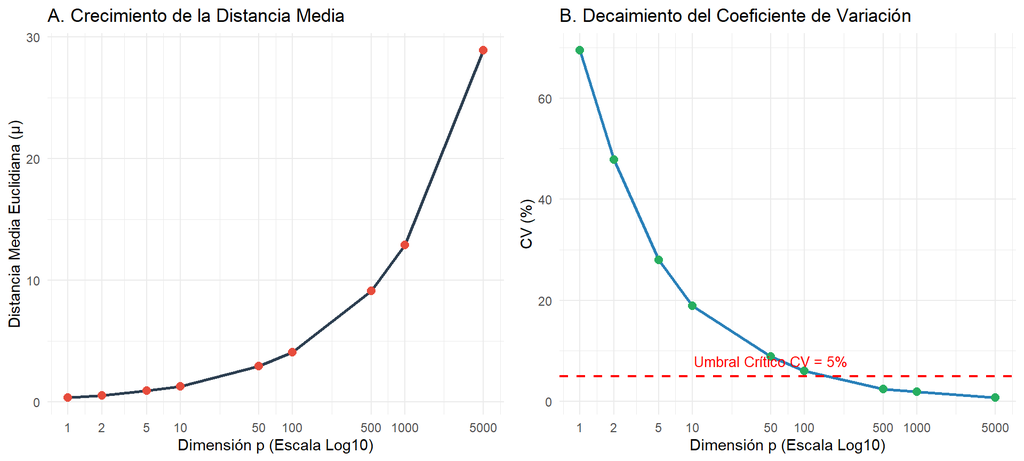

```r
# Gráfico A: Crecimiento de la Distancia Media
p1 <- ggplot(tabla_euc, aes(x = Dimension_p, y = Distancia_Media)) +
  geom_line(color = "#2c3e50", size = 1) +
  geom_point(color = "#e74c3c", size = 2.5) +
  scale_x_log10(breaks = dimensiones) +
  labs(
    title = "A. Crecimiento de la Distancia Media",
    x = "Dimensión p (Escala Log10)",
    y = "Distancia Media Euclidiana (μ)"
  ) +
  theme_minimal()

# Gráfico B: Decaimiento del Coeficiente de Variación (CV)
p2 <- ggplot(tabla_euc, aes(x = Dimension_p, y = CV_Porcentaje)) +
  geom_line(color = "#2980b9", size = 1) +
  geom_point(color = "#27ae60", size = 2.5) +
  geom_hline(yintercept = 5, linetype = "dashed", color = "red", size = 0.8) +
  annotate("text", x = 50, y = 8, label = "Umbral Crítico CV = 5%", color = "red", size = 3.5) +
  scale_x_log10(breaks = dimensiones) +
  labs(
    title = "B. Decaimiento del Coeficiente de Variación",
    x = "Dimensión p (Escala Log10)",
    y = "CV (%)"
  ) +
  theme_minimal()

# Disposición en paralelo
grid.arrange(p1, p2, ncol = 2)
```

### 4. Repita el punto 1 usando distancia coseno en lugar de euclidiana. ¿Se concentra igual de rápido?

La distancia coseno se define a partir de la similitud angular entre dos vectores $u, v \in \mathbb{R}^p$:

$$d_{\text{cos}}(u, v) = 1 - \frac{\langle
u, v \rangle}{\|u\|_2 \|v\|_2} = 1 - \frac{\sum_{j=1}^p u_j
v_j}{\sqrt{\sum_{j=1}^p u_j^2} \sqrt{\sum_{j=1}^p v_j^2}}$$

Replicamos el procedimiento utilizando la distancia Coseno:

```r
# Función auxiliar para distancia coseno entre dos vectores
dist_coseno_vec <- function(u, v) {
  norm_u <- sqrt(sum(u^2))
  norm_v <- sqrt(sum(v^2))
  if (norm_u == 0 || norm_v == 0) return(0)
  sim_cos <- sum(u * v) / (norm_u * norm_v)
  return(1 - sim_cos)
}

# Simulación para Distancia Coseno
set.seed(42)
res_cos <- sapply(dimensiones, function(p) {
  puntos <- matrix(runif(500 * p), nrow = 500, ncol = p)

  if (p == 1) {
    # En p = 1, vectores reales positivos en tienen ángulo 0° (coseno = 1, dist = 0)
    return(c(media = 0, desv = 0, cv_pct = 0))
  }

  dists <- sapply(1:200, function(i) {
    dist_coseno_vec(puntos[i, ], puntos[i + 200, ])
  })

  media <- mean(dists)
  desv  <- sd(dists)
  cv    <- (desv / media) * 100

  c(media = media, desv = desv, cv_pct = cv)
})

# Construcción de la tabla comparativa
tabla_comparativa <- tibble(
  Dimension_p   = dimensiones,
  Euc_Media     = round(res_euc["media", ], 4),
  Euc_CV_pct    = round(res_euc["cv_pct", ], 2),
  Cos_Media     = round(res_cos["media", ], 4),
  Cos_CV_pct    = round(res_cos["cv_pct", ], 2)
)

kable(
  tabla_comparativa,
  format = "html",
  caption = "Tabla 4.2: Comparación de Concentración de Distancias: Euclidiana vs. Coseno",
  col.names = c("Dimensión (p)", "Media Euclidiana", "CV Euclidiano (%)", "Media Coseno", "CV Coseno (%)"),
  table.attr = 'class="table table-striped table-hover table-bordered table-condensed"'
) %>%
  kable_styling(full_width = FALSE, bootstrap_options = c("striped", "hover", "condensed"))
```

Tabla 4.2: Comparación de Concentración de Distancias: Euclidiana vs. Coseno

| Dimensión (p) | Media Euclidiana | CV Euclidiano (%) | Media Coseno | CV Coseno (%) |
| --- | --- | --- | --- | --- |
| 1 | 0.3360 | 69.42 | 0.0000 | 0.00 |
| 2 | 0.5175 | 47.81 | 0.1706 | 123.70 |
| 5 | 0.8949 | 27.96 | 0.2317 | 60.38 |
| 10 | 1.2650 | 18.88 | 0.2424 | 40.78 |
| 50 | 2.9058 | 8.82 | 0.2554 | 19.70 |
| 100 | 4.0450 | 6.05 | 0.2439 | 12.58 |
| 500 | 9.0956 | 2.48 | 0.2484 | 5.44 |
| 1000 | 12.8877 | 1.86 | 0.2493 | 3.84 |
| 5000 | 28.8918 | 0.75 | 0.2503 | 1.68 |